# Part II, INTRODUCTION TO MACHINE LEARNING

#### 3.2.0.1 Let us test the sparsity enforcement by adding non informative columns:

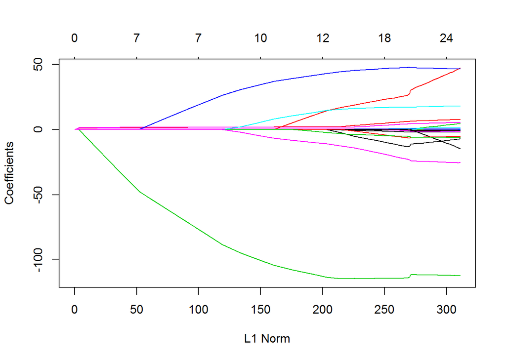

```r
data(Hitters)
Hitters = na.omit(Hitters)
x=model.matrix(Salary~.,Hitters)[,-1]
y=Hitters$Salary


#add 1 noise column:
#the below would work for data frames
set.seed(1)
noise=matrix(rnorm(5*263),ncol=5 )
x = cbind(x, noise)
#add any polynomial terms you like

myFirstLassoFit =glmnet(x,y,alpha=1,lambda=grid)

plot(myFirstLassoFit)
```

```r
coefs = as.matrix(coef(myFirstLassoFit))

#COMMENT: sparse matrices often have their own class !!

#
# x$n1 = rnorm(nrow(x))
# x$n2 = rnorm(nrow(x))
# x$n3 = rnorm(nrow(x))
# x$n4 = rnorm(nrow(x))
# x$n5 = rnorm(nrow(x))
```

## 3.3 Elastic Net

### 3.3.1 The mystery of the additional $\alpha$ paramater

- The elastic net for correlated variables, which uses a penalty that is part L1, part L2.
- Compromise between the ridge regression penalty $(\alpha = 0)$ and the lasso penalty $(\alpha = 1)$.
- This penalty is particularly useful in the $p >> N$ situation, or any situation where there are many correlated predictor variables.

### 3.3.2 Exercise 1

#### 3.3.2.1 For the churn data, find the sparsest model with the best prediction on a hold out set. Compare with the full model. (BTW, does this data set look familiar at all ?)

```r
churn <- read.csv("data/churn.csv", stringsAs=TRUE)
set.seed(1)
train=sample( nrow(churn), 400)

fitSmall = glm(Churn ~ CellPlan + Sex + Age, data = churn[train,], family = binomial)
predSmall = predict(fitSmall, newdata = churn[-train,], type="response")
(ConfMatSmall = table(predSmall>0.5,churn[-train,"Churn"]))
(Accuracy = round(sum(diag(ConfMatSmall))/sum(ConfMatSmall) , 2))

####big model:

fitBig = glm(Churn ~ . , data = churn[train,-14], family = binomial)
predBig = predict(fitBig, newdata = churn[-train,], type="response")
(ConfMatBig = table(predBig>0.5,churn[-train,"Churn"]))
(Accuracy = round(sum(diag(ConfMatBig))/sum(ConfMatBig) , 2))
```

[output not shown]

### 3.3.3 Exercise 2

In this exercise, we will predict the number of applications received using the other variables in the College data set.

1. Split the data set into a training set and a test set.
2. Fit a linear model using least squares on the training set, and report the test error obtained.
3. Fit a ridge regression model on the training set, with $\lambda$ chosen by cross-validation. Report the test error obtained.
4. Fit a lasso model on the training set, with $\lambda$ chosen by crossvalidation. Report the test error obtained, along with the number of non-zero coefficient estimates.

### 3.3.4 Many Variables

https://www.kaggle.com/c/house-prices-advanced-regression-techniques/data

https://www.kaggle.com/dsysoev/house-prices-advanced-regression-techniques/lasso-ridge-and-elasticnet-comparison

```r
train_HousePrices <- read_csv("H:/DropboxHWR/SS2017/AnalyticsLab/data/kaggle/HousePrices/train.csv.gz")
```

# 4 Appendix

## 4.1 model.matrix and matrix multiplication

```r
mm = model.matrix(Churn ~ ., data = churn[train,-14])#28 columns
dim(mm)
```

```
## [1] 131 112
```

```r
library(ISLR)
data(Hitters)
Hitters=na.omit(Hitters)

SalaryModel = lm(Salary~ Hits + PutOuts + CRBI,data=Hitters)
head(predict(SalaryModel))
```

```
##       -Alan Ashby      -Alvin Davis     -Andre Dawson -Andres Galarraga
##         611.11976         715.34087         950.55323         424.10211
##  -Alfredo Griffin        -Al Newman
##         708.86493          59.21692
```

```r
library(dplyr)
SalaryModel$coef
```

```
## (Intercept)        Hits     PutOuts        CRBI
## -71.4592204   2.8038162   0.2735814   0.6825275
```

```r
head(select(Hitters, Hits, PutOuts, CRBI))
```

```
##                   Hits PutOuts CRBI
## -Alan Ashby         81     632  414
## -Alvin Davis       130     880  266
## -Andre Dawson      141     200  838
## -Andres Galarraga   87     805   46
## -Alfredo Griffin   169     282  336
## -Al Newman          37      76    9
```

```r
(CoefTimesData = SalaryModel$coef * c(1, as.matrix(Hitters[1, c("Hits", "PutOuts", "CRBI")])) )
```

```
## (Intercept)        Hits     PutOuts        CRBI
##   -71.45922   227.10911   172.90347   282.56640
```

```r
sum(CoefTimesData)
```

```
## [1] 611.1198
```

## 4.2 heart disease data

https://statweb.stanford.edu/~tibs/ElemStatLearn/datasets/SAheart.info.txt

A retrospective sample of males in a heart-disease high-risk region of the Western Cape, South Africa. There are roughly two controls per case of CHD. Many of the CHD positive men have undergone blood pressure reduction treatment and other programs to reduce their risk factors after their CHD event. In some cases the measurements were made after these treatments. These data are taken from a larger dataset, described in Rousseauw et al, 1983, South African Medical Journal.

sbp systolic blood pressure tobacco cumulative tobacco (kg) ldl low density lipoprotein cholesterol adiposity famhist family history of heart disease (Present, Absent) typea type-A behavior obesity alcohol current alcohol consumption age age at onset chd response, coronary heart disease

To read into R: read.table(“http://www-stat.stanford.edu/~tibs/ElemStatLearn/datasets/SAheart.data”, sep=“,”,head=T,row.names=1)